#### 26.2.25

# Week 6 Granger Causality and VAR models

### Part 1 – 20 pts Exploratory Data Analysis

```python
import pandas as pd
import numpy as np
import matplotlib.pyplot as plt
import seaborn as sns
```

#### A: 10 pts Perform quantitative and qualitative EDA

```python
df = pd.read_csv("/Users/Devyani/msads/timeseries/hw6/hw6_data_var.csv")
```

```python
df.head()
```

|  | Unnamed: 0 | PCE | AHE | PCEPI |
| --- | --- | --- | --- | --- |
| 0 | 3/1/2006 | 9122.1 | 20.04 | 88.473 |
| 1 | 4/1/2006 | 9174.8 | 20.17 | 88.850 |
| 2 | 5/1/2006 | 9215.1 | 20.13 | 89.070 |
| 3 | 6/1/2006 | 9240.8 | 20.22 | 89.285 |
| 4 | 7/1/2006 | 9322.6 | 20.30 | 89.601 |

```python
summary_stats = df.describe()
print(summary_stats)
```

```
                PCE         AHE       PCEPI
count    166.000000  166.000000  166.000000
mean   11507.872289   23.938193  100.006169
std     1630.579647    2.235573    6.028324
min     9122.100000   20.040000   88.473000
25%    10009.000000   22.237500   95.145000
50%    11204.100000   23.765000  100.861000
75%    12789.900000   25.675000  104.186250
max    14796.300000   28.360000  110.750000
```

```python
missing_values = df.isnull().sum()
display(missing_values)
```

```
Unnamed: 0    0
PCE           0
AHE           0
PCEPI         0
dtype: int64
```

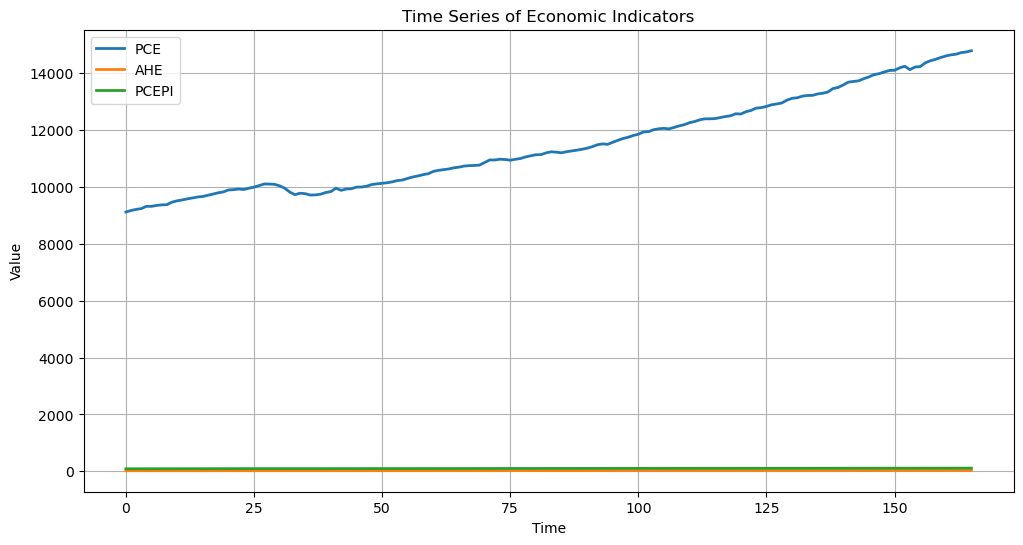

```python
plt.figure(figsize=(12, 6))
plt.plot(df.index, df['PCE'], label='PCE', linewidth=2)
plt.plot(df.index, df['AHE'], label='AHE', linewidth=2)
plt.plot(df.index, df['PCEPI'], label='PCEPI', linewidth=2)
plt.legend()
plt.title("Time Series of Economic Indicators")
plt.xlabel("Time")
plt.ylabel("Value")
plt.grid()
plt.show()
```

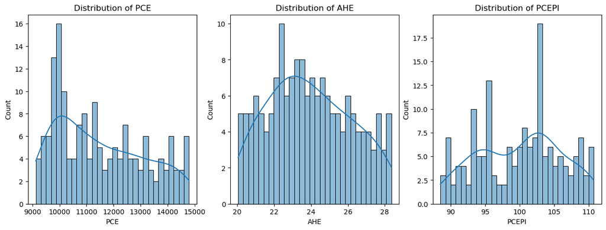

```python
fig, axes = plt.subplots(1, 3, figsize=(15, 5))
for i, col in enumerate(['PCE', 'AHE', 'PCEPI']):
    sns.histplot(df[col], bins=30, kde=True, ax=axes[i])
    axes[i].set_title(f'Distribution of {col}')
plt.show()
```

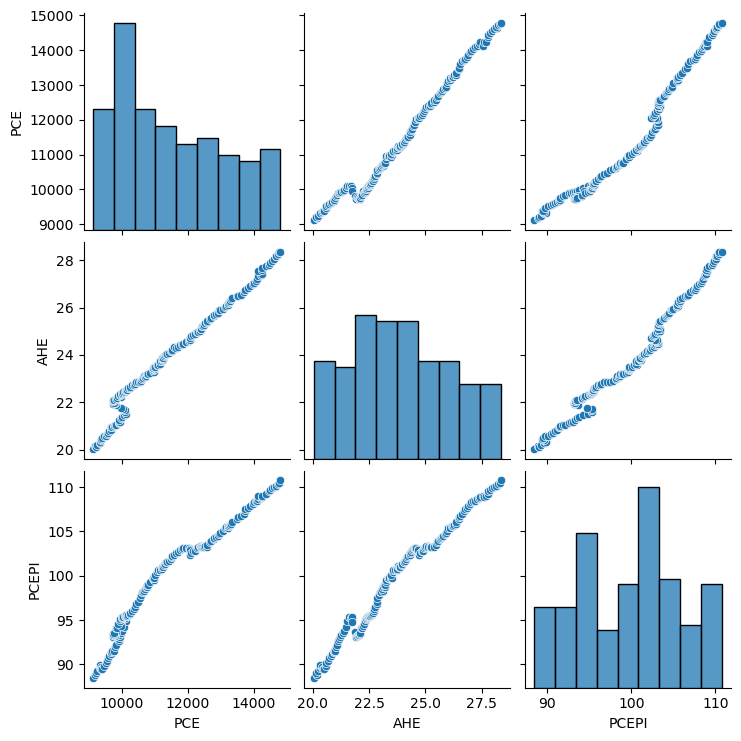

```python
sns.pairplot(df)
plt.show()
```

```python
df.iloc[:, 0] = pd.to_datetime(df.iloc[:, 0], errors='coerce')
```

```python
numeric_df = df.select_dtypes(include=['number'])
```

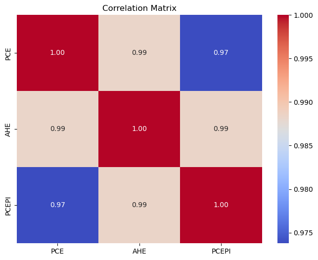

```python
plt.figure(figsize=(8, 6))
sns.heatmap(numeric_df.corr(), annot=True, cmap='coolwarm', fmt=".2f")
plt.title("Correlation Matrix")
plt.show()
```

### Part 2 – 40 pts Granger Causality

```python
from statsmodels.tsa.stattools import grangercausalitytests
```

#### A: 8 pts Consider PCE and AHE, give an intuitive description of the relationship between the two economic measures. This is your opinion, looking for logic and understanding not right or wrong

Intuitively, we can assume changes in **PCE** can influence **AHE**. When consumers spend more, businesses generate higher revenues, leading to potential wage increases due to labour demand. Thus, we hypothesise that PCE Granger-causes AHE, and investigate **PCE -> AHE**.

#### B: 8 pts Difference the two variables

```python
df_diff = df.diff().dropna()
```

#### C: 8 pts Check Granger Causality for the direction you stated in 2A, return plot of results

```python
result_pce_ahe = grangercausalitytests(df_diff[['AHE', 'PCE']], maxlag=4, verbose=True)
```

```
Granger Causality
number of lags (no zero) 1
ssr based F test:         F=0.0186  , p=0.8917  , df_denom=161, df_num=1
ssr based chi2 test:   chi2=0.0189  , p=0.8906  , df=1
likelihood ratio test: chi2=0.0189  , p=0.8906  , df=1
parameter F test:         F=0.0186  , p=0.8917  , df_denom=161, df_num=1

Granger Causality
number of lags (no zero) 2
ssr based F test:         F=1.1373  , p=0.3233  , df_denom=158, df_num=2
ssr based chi2 test:   chi2=2.3466  , p=0.3094  , df=2
likelihood ratio test: chi2=2.3298  , p=0.3119  , df=2
parameter F test:         F=1.1373  , p=0.3233  , df_denom=158, df_num=2

Granger Causality
number of lags (no zero) 3
ssr based F test:         F=1.7396  , p=0.1612  , df_denom=155, df_num=3
ssr based chi2 test:   chi2=5.4546  , p=0.1414  , df=3
likelihood ratio test: chi2=5.3648  , p=0.1470  , df=3
parameter F test:         F=1.7396  , p=0.1612  , df_denom=155, df_num=3

Granger Causality
number of lags (no zero) 4
ssr based F test:         F=1.7223  , p=0.1479  , df_denom=152, df_num=4
ssr based chi2 test:   chi2=7.2970  , p=0.1210  , df=4
likelihood ratio test: chi2=7.1365  , p=0.1288  , df=4
parameter F test:         F=1.7223  , p=0.1479  , df_denom=152, df_num=4
```

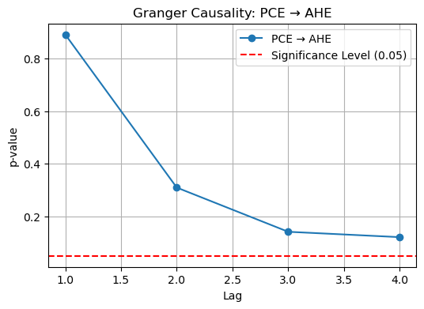

```python
p_values_pce_ahe = [result_pce_ahe[i+1][0]['ssr_chi2test'][1] for i in range(4)]
plt.figure(figsize=(6, 4))
plt.plot(range(1, 5), p_values_pce_ahe, marker='o', linestyle='-', label='PCE → AHE')
plt.axhline(y=0.05, color='r', linestyle='--', label='Significance Level (0.05)')
plt.title("Granger Causality: PCE → AHE")
plt.xlabel("Lag")
plt.ylabel("p-value")
plt.legend()
plt.grid()
plt.show()
```

#### D: 8 pts Check Granger Causality for the opposite direction you stated in 2A, return plot of results

```python
result_ahe_pce = grangercausalitytests(df_diff[['PCE', 'AHE']], maxlag=4, verbose=True)
```

```
Granger Causality
number of lags (no zero) 1
ssr based F test:         F=0.0285  , p=0.8662  , df_denom=161, df_num=1
ssr based chi2 test:   chi2=0.0290  , p=0.8648  , df=1
likelihood ratio test: chi2=0.0290  , p=0.8648  , df=1
parameter F test:         F=0.0285  , p=0.8662  , df_denom=161, df_num=1

Granger Causality
number of lags (no zero) 2
ssr based F test:         F=0.1227  , p=0.8846  , df_denom=158, df_num=2
ssr based chi2 test:   chi2=0.2531  , p=0.8811  , df=2
likelihood ratio test: chi2=0.2529  , p=0.8812  , df=2
parameter F test:         F=0.1227  , p=0.8846  , df_denom=158, df_num=2

Granger Causality
number of lags (no zero) 3
ssr based F test:         F=0.1740  , p=0.9138  , df_denom=155, df_num=3
ssr based chi2 test:   chi2=0.5457  , p=0.9087  , df=3
likelihood ratio test: chi2=0.5448  , p=0.9089  , df=3
parameter F test:         F=0.1740  , p=0.9138  , df_denom=155, df_num=3

Granger Causality
number of lags (no zero) 4
ssr based F test:         F=0.5205  , p=0.7208  , df_denom=152, df_num=4
ssr based chi2 test:   chi2=2.2052  , p=0.6981  , df=4
likelihood ratio test: chi2=2.1903  , p=0.7008  , df=4
parameter F test:         F=0.5205  , p=0.7208  , df_denom=152, df_num=4
```

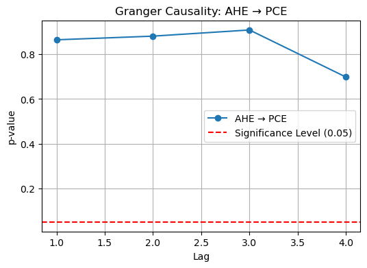

```python
p_values_ahe_pce = [result_ahe_pce[i+1][0]['ssr_chi2test'][1] for i in range(4)]
plt.figure(figsize=(6, 4))
plt.plot(range(1, 5), p_values_ahe_pce, marker='o', linestyle='-', label='AHE → PCE')
plt.axhline(y=0.05, color='r', linestyle='--', label='Significance Level (0.05)')
plt.title("Granger Causality: AHE → PCE")
plt.xlabel("Lag")
plt.ylabel("p-value")
plt.legend()
plt.grid()
plt.show()
```

#### E: 8 pts Summarize your findings. You must understand the underlying null hypothesis of test.

These tests suggest that we fail to reject the null hypothesis in both directions, in that PCE does not cause AHE and AHE does not cause PCE.

### Part 3 – 40 pts VARMA modeling

```python
from statsmodels.tsa.api import VAR
from sklearn.metrics import mean_squared_error
```

#### A: 10 pts Using differenced data, run a search to find the best fit order for AH, PCE, and PCEIP, return a plot

```python
df.iloc[:, 0] = pd.to_datetime(df.iloc[:, 0], errors='coerce')
df.set_index(df.columns[0], inplace=True)
```

```python
df = df.apply(pd.to_numeric, errors='coerce')
```

```python
df_diff = df.diff().dropna()
```

```python
df_diff = df_diff.apply(pd.to_numeric, errors='coerce')
```

```python
model = VAR(df_diff)
lag_selection = model.select_order(maxlags=10)
optimal_lag = lag_selection.aic
print(f"Optimal lag order based on AIC: {optimal_lag}")
```

```
Optimal lag order based on AIC: 5
```

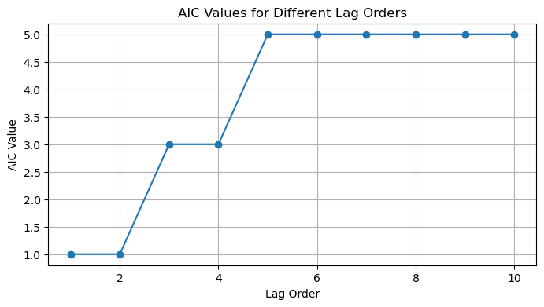

```python
plt.figure(figsize=(8, 4))
plt.plot(range(1, 11), [model.select_order(maxlags=i).aic for i in range(1, 11)], marker='o', linestyle='-')
plt.xlabel("Lag Order")
plt.ylabel("AIC Value")
plt.title("AIC Values for Different Lag Orders")
plt.grid()
plt.show()
```

#### B: 10 pts Fit the VAR model with chosen order, return the model summary.

```python
var_model = model.fit(optimal_lag)
print(var_model.summary())
```

```
  Summary of Regression Results
==================================
Model:                         VAR
Method:                        OLS
Date:           Wed, 26, Feb, 2025
Time:                     12:41:20
--------------------------------------------------------------------
No. of Equations:         3.00000    BIC:                   -2.51269
Nobs:                     160.000    HQIC:                  -3.06063
Log likelihood:          -358.271    FPE:                  0.0322824
AIC:                     -3.43524    Det(Omega_mle):       0.0242542
--------------------------------------------------------------------
Results for equation PCE
===========================================================================
              coefficient       std. error           t-stat            prob
---------------------------------------------------------------------------
const           24.399614        11.866251            2.056           0.040
L1.PCE           0.007737         0.095039            0.081           0.935
L1.AHE          62.263661       105.145106            0.592           0.554
L1.PCEPI        51.717566        20.639162            2.506           0.012
L2.PCE           0.156396         0.097334            1.607           0.108
L2.AHE          90.929687       109.256467            0.832           0.405
L2.PCEPI       -20.417383        21.605347           -0.945           0.345
L3.PCE           0.170083         0.096036            1.771           0.077
L3.AHE         -18.412372        97.562256           -0.189           0.850
L3.PCEPI       -44.092382        21.529261           -2.048           0.041
L4.PCE           0.143076         0.097765            1.463           0.143
L4.AHE        -122.916604       106.217346           -1.157           0.247
L4.PCEPI         1.463829        21.917005            0.067           0.947
L5.PCE           0.080231         0.098087            0.818           0.413
L5.AHE         -83.670926       102.735010           -0.814           0.415
L5.PCEPI       -30.653975        19.270311           -1.591           0.112
===========================================================================

Results for equation AHE
===========================================================================
              coefficient       std. error           t-stat            prob
---------------------------------------------------------------------------
const            0.019340         0.008963            2.158           0.031
L1.PCE          -0.000023         0.000072           -0.316           0.752
```

[output cut: 28 more lines]

```
L3.AHE          -0.187756         0.446176           -0.421           0.674
L3.PCEPI        -0.049795         0.098459           -0.506           0.613
L4.PCE          -0.000274         0.000447           -0.612           0.540
L4.AHE          -0.773267         0.485758           -1.592           0.111
L4.PCEPI         0.130271         0.100232            1.300           0.194
L5.PCE          -0.000042         0.000449           -0.093           0.926
L5.AHE          -0.832288         0.469833           -1.771           0.076
L5.PCEPI        -0.164446         0.088128           -1.866           0.062
===========================================================================

Correlation matrix of residuals
              PCE       AHE     PCEPI
PCE      1.000000 -0.020803  0.492766
AHE     -0.020803  1.000000  0.037719
PCEPI    0.492766  0.037719  1.000000
```

#### C: 10 pts Create 12 periods of forecast for all three variables, return plots of predicted values against actual values, Return variable level RMSE (3 total)

```python
forecast_steps = 12
forecast_input = df_diff.values[-optimal_lag:]
forecast = var_model.forecast(y=forecast_input, steps=forecast_steps)
forecast_df = pd.DataFrame(forecast, columns=df_diff.columns)
```

```python
last_values = df.iloc[-1]
forecast_actual = forecast_df.cumsum() + last_values.values
```

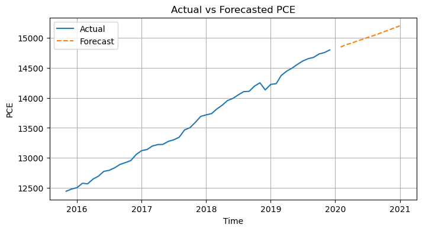

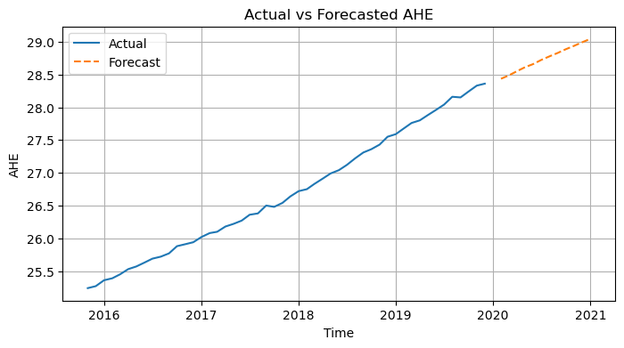

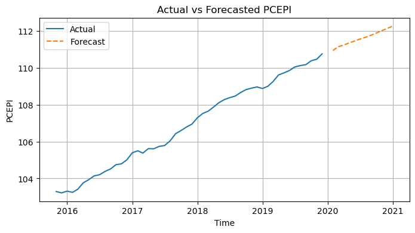

```python
for col in df_diff.columns:
    plt.figure(figsize=(8, 4))
    plt.plot(df.index[-50:], df[col].iloc[-50:], label='Actual')
    plt.plot(pd.date_range(df.index[-1], periods=forecast_steps + 1, freq='M')[1:],
             forecast_actual[col], label='Forecast', linestyle='dashed')
    plt.title(f'Actual vs Forecasted {col}')
    plt.xlabel('Time')
    plt.ylabel(col)
    plt.legend()
    plt.grid()
    plt.show()
```

```python
rmse_values = {}
for col in df_diff.columns:
    actual_values = df[col].iloc[-forecast_steps:].values
    predicted_values = forecast_actual[col].values[:forecast_steps]
    rmse = np.sqrt(mean_squared_error(actual_values, predicted_values))
    rmse_values[col] = rmse
```

```python
print("RMSE for each variable:")
print(rmse_values)
```

```
RMSE for each variable:
{'PCE': 480.5081396695805, 'AHE': 0.7500200330390424, 'PCEPI': 1.7677579281009184}
```

#### D: 10 pts What is the advantage of this VAR model? What would ARIMA or prophet models on this dataset look like, if we were asked to forecast AHE?

- VAR is the best choice when forecasting AHE in relation to other indicators like PCE and PCEPI, as it captures interdependencies.
- ARIMA works well for purely autoregressive forecasting, but it ignores external variables. While ARIMA can work well when AHE follows an autoregressive pattern, it does not incorporate the effects of PCE and PCEPI, which could reduce its accuracy in capturing macroeconomic trends.
- Prophet is great for long-term trends and seasonal forecasting, but may not be the most suitable for analysis where relationships between variables matter.